# The STR Dataset

The STR Dataset *FrenchSTRs.dat* contains genotype information (STRs) of individuals from a French population. The first column of the data set contains an identifier the individual. STR data starts at the second column.

## Exercise 1

Before starting this part of the assignment we must import he data set into R.

```r
FrenchSTRs <- read.table("FrenchSTRs.dat", quote="\"", comment.char="")
```

## Exercise 2

**How many individuals and how many STRs contains the database?**

In order to know the number of individuals we execute the following command.

```r
length(unique(FrenchSTRs$Individual))
```

```
## [1] 29
```

Also we want to know the number of STR in the data set, that is computed by selecting the number of variables and substracting one, because, the first one is the ID of the individual.

```r
ncol(FrenchSTRs)-1
```

```
## [1] 678
```

## Exercise 3

**The value -9 indicates a missing value. Replace all missing values by NA. What percentage of the total amount of datavalues is missing?**

In order to change all the -9 to NA we use the following command to select all the -9 in the data set and replacing them for a NA.

```r
FrenchSTRs[FrenchSTRs == -9] = NA
```

Computing the % of missing values is done in the following command.

```r
(sum(length(which(is.na(FrenchSTRs))))/(ncol(FrenchSTRs)*nrow(FrenchSTRs)))*100
```

```
## [1] 4.199888
```

## Exercise 4

**Write a function that determines the number of alleles for a STR. Determine the number of alleles for each STR in the database. Compute basic descriptive statistics of the number of alleles (mean, standard deviation, median, minimum, maximum).**

We have done this exercise by creating a function to be more efficient that using a for, due that are specially ineficient in R.

We have created a function and then, using apply, we executed it for the whole dataset.

The function name is countAlleles, just count Alleles like the one that was implemented in the example code.

We end by computing a summary that will give us all the information we need except the standard deviation that is computed using the method sd.

```r
countAlleles <- function(x){
  y <- length(unique(x[!is.na(x)]))
  return(y)
}
resultAlleles = apply(FrenchSTRs, 2, countAlleles)
#summary of the result
summary(resultAlleles)
```

```
##    Min. 1st Qu.  Median    Mean 3rd Qu.    Max.
##   3.000   5.000   6.000   6.408   7.000  29.000
```

```r
#standard deviation
sd(resultAlleles)
```

```
## [1] 2.018351
```

## Exercise 5

**Make a table with the number of STRs for a given number of alleles and present a barplot of the number STRs in each category. What is the most common number of alleles for an STR?**

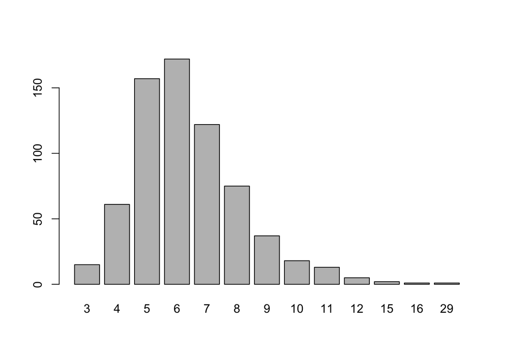

```r
barplot(table(resultAlleles))
```

## Exercise 6

For this exercise we also created a function and used the apply R function to be more efficient.

```r
expectedHeterozygote <- function(x){
  1-sum((unique(table(x[!is.na(x)]))/length(x))^2) #formula from slides.
}
resultExpected = apply(FrenchSTRs, 2, expectedHeterozygote)
summary(resultExpected)
```

```
##    Min. 1st Qu.  Median    Mean 3rd Qu.    Max.
##  0.3757  0.6910  0.7574  0.7502  0.8141  0.9988
```

## Exercise 7

**Compare the results you obtained for the SNP database with those you obtained for the STR database. What differences do you observe between these two types of genetic markers?**